# Permutation-based significance testing

Author: Joyce Hsiao

Last updated: 2015-09-09 07:23:10

view source

```r
library(Biobase)

## Set working directories
dir <- "../"
figdir <- file.path(dir,"figures")
rdadir <- file.path(dir,"rdas")
datadir <- file.path(dir, "data")

## Use broman package for colors
require(broman)
crayon <- brocolors("crayons")

## Load customized packages
require(devtools)
require(Humanzee)
```

# Goal

Permutation-based significance testing for the interaction models. We observed in our differential divergence analysis comparing species difference between phenotypes (RNA vs. Ribo, RNA vs. Protein, and Ribo vs. Protein) an odd p-value distribution (http://jhsiao999.github.io/primate_ribo/project/analysis/compare-ribo-rna-quantified-in-sequencing.html). Therefore, we decided to compute permutation-based p-values for all the interaction tests. The goal of the permutation is to construct an empirical null distribution for the interaction effect. Three permutation schemes are proposed as follows:

1. *Shuffle across species and technology*: For each gene and each inter-species comparison of RNA, Ribo or protein levels, we shuffle the sample labels across species and also technology type for 1000 times. The empirical p-value is computed as the proportion of permutation-based test statistic that is greater than the observed test statistic. Likelihood ratio test statistic (chi-squared) is used to test the interaction effect.
2. *Shuffle within speciees across technology*: For each gene and each inter-species comparison of RNA, Ribo or protein levels, we shuffle the sample labels with each species and across techology for 1000 times. The empirical p-value is computed as the proportion of permutation-based test statistic that is greater than the observed test statistic. Likelihood ratio test statistic (chi-squared) is used to test the interaction effect.
3. *Shuffle within technology across species*: For each gene and each inter-species comparison of RNA, Ribo or protein levels, we shuffle the sample labels with each technology type and across species for 1000 times. The empirical p-value is computed as the proportion of permutation-based test statistic that is greater than the observed test statistic. Likelihood ratio test statistic (chi-squared) is used to test the interaction effect.

We used the *permute-interact-per-gene* function in the Humanzee package for generating the permuted data sets and interaction results are recorded in *permute-interact-per-gene.r*. Each permutation set of results of 3,188 genes was produced on *midway* using 1 clustering and 10 nodes, taking 3 and a half hours to completion.

# Interaction analysis

Run interaction anlaysis to include the value of likelihood ratio statistic of the interaction analysis of each gene. Note that the results here are exactly the same as those saved in *TEnew.rda*, *ribopro.rda*, and *rnapro.rda*, with the addition of Likelihood ratio statistics.

```r
# RNA vs. Ribo
load(file.path(rdadir, "eSetRRP.rda"))
eset <- eSetRRP.RP.Q.log2[ ,eSetRRP.RP.Q.log2$seqData!="protein" &
                            eSetRRP.RP.Q.log2$species!="rhesus"]
res.riborna_LR <- interact2way(eset)

# Ribo vs. Protein
load(file.path(rdadir, "ribopro.rda"))
eset <- eSetRRP.log2.Qmed[ ,eSetRRP.log2.Qmed$seqData!="rna" &
                            eSetRRP.log2.Qmed$species!="rhesus"]
res.ribopro_LR <- interact2way(eset)

# RNA vs. Protein
load(file.path(rdadir, "rnapro.rda"))
eset <- eSetRRP.log2.Qmed[ ,eSetRRP.log2.Qmed$seqData!="ribo" &
                            eSetRRP.log2.Qmed$species!="rhesus"]
res.rnapro_LR <- interact2way(eset)

save(res.riborna_LR, res.ribopro_LR, res.rnapro_LR,
     file = file.path(rdadir, "diff_diver_LR.rda"))
```

Helper function for computing empirical p-value

```r
get_perm_pvals <- function(perm_data, obs_data) {
    n_simu <- length(perm_data)
    n_genes <- dim(obs_data)[1]
    perm_pvalues <- sapply(1: n_genes, function(per_gene) {
                            n_larger <- sapply(perm_data, function(per_permute) {
                                            per_permute[per_gene, "LRatio"] > obs_data[per_gene, "LRatio"]
                                        })
                            n_larger <- sum(n_larger, na.rm = TRUE)
                            if (n_larger > 0) {
                                pval <- n_larger/n_simu
                            }
                            if (n_larger ==0) {
                                pval <- 1/n_simu
                            }
                            return(pval)
                          })
  return(perm_pvalues)
}
```

# Within technology

```r
# Permuted results are saved locally on Joyce Hsiao's computer
# Not enough storage space on GitHub

permute_dir <- "~/Dropbox/Github/primate_ribo_rdas_permute/"

# Interaction test results
# Sample lables shuffled within technologies
load(file.path(permute_dir, "permute-per-gene-seqData", "res-null-ribo-rna-seqData.rda"))
load(file.path(permute_dir, "permute-per-gene-seqData", "res-null-ribo-pro-seqData.rda"))
load(file.path(permute_dir, "permute-per-gene-seqData", "res-null-rna-pro-seqData.rda"))
```

Each of the rdas contains 1,000 data.frames of 3,188 genes' results of Likelihood ratio statistics, associated p-values, and q-values (using qvalue package).

For each gene *i*, the null distribution of its LR statistic is the distribution of the LR statistics across the 1,000 permutations.

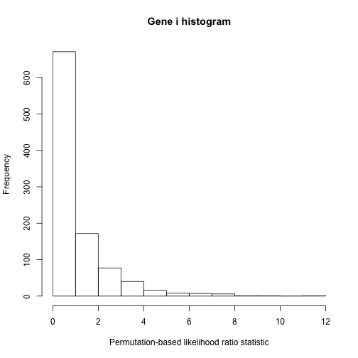

```r
gene_i <- sapply(res_null_ribo_rna_seqData, function(per_permute) {
                  per_permute$LRatio[1]
                })

hist(gene_i, main = "Gene i histogram",
     xlab = "Permutation-based likelihood ratio statistic")
```

```r
load(file.path(rdadir, "diff_diver_LR.rda"))

# Compute empirical p-value for every gene
riborna_perm_seqData <- get_perm_pvals(res_null_ribo_rna_seqData, res.riborna_LR)
ribopro_perm_seqData <- get_perm_pvals(res_null_ribo_pro_seqData, res.ribopro_LR)
rnapro_perm_seqData <- get_perm_pvals(res_null_rna_pro_seqData, res.rnapro_LR)


save(riborna_perm_seqData, ribopro_perm_seqData,
     rnapro_perm_seqData, file = file.path(rdadir, "null_interact_seqData.rda") )
```

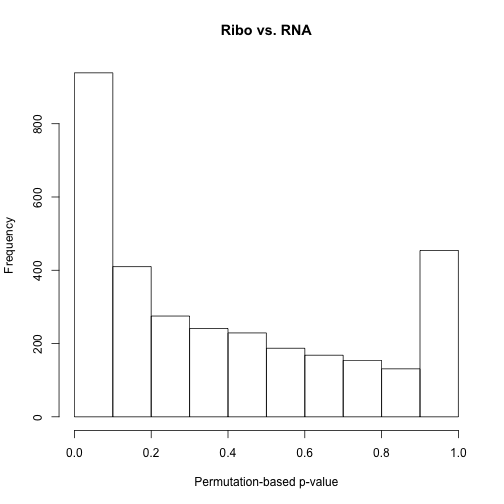

```r
load(file.path(rdadir, "null_interact_seqData.rda"))
hist(riborna_perm_seqData, main = "Ribo vs. RNA",
     xlab = "Permutation-based p-value")
```

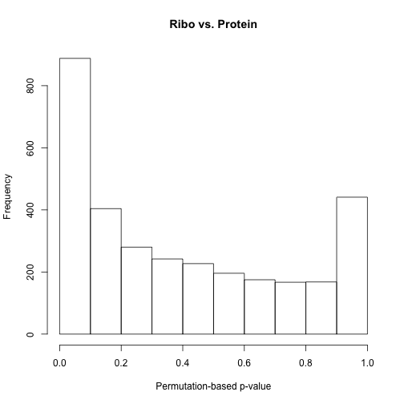

```r
hist(ribopro_perm_seqData, main = "Ribo vs. Protein",
     xlab = "Permutation-based p-value")
```

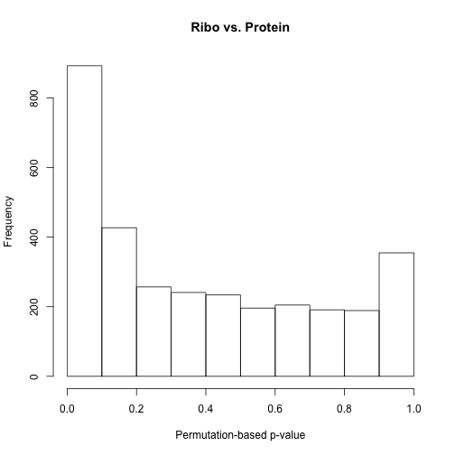

```r
hist(rnapro_perm_seqData, main = "Ribo vs. Protein",
     xlab = "Permutation-based p-value")
```

# Within species

```r
# Permuted results are saved locally on Joyce Hsiao's computer
# Not enough storage space on GitHub

permute_dir <- "~/Dropbox/Github/primate_ribo_rdas_permute/"

# Interaction test results
# Sample lables shuffled within technologies
load(file.path(permute_dir, "permute-per-gene-species", "res-null-ribo-rna-species.rda"))
load(file.path(permute_dir, "permute-per-gene-species", "res-null-ribo-pro-species.rda"))
load(file.path(permute_dir, "permute-per-gene-species", "res-null-rna-pro-species.rda"))
```

Each of the rdas contains 1,000 data.frames of 3,188 genes' results of Likelihood ratio statistics, associated p-values, and q-values (using qvalue package).

```r
load(file.path(rdadir, "diff_diver_LR.rda"))

# Compute empirical p-value for every gene
riborna_perm_species <- get_perm_pvals(res_null_ribo_rna_species, res.riborna_LR)
ribopro_perm_species <- get_perm_pvals(res_null_ribo_pro_species, res.ribopro_LR)
rnapro_perm_species <- get_perm_pvals(res_null_rna_pro_species, res.rnapro_LR)


save(riborna_perm_species, ribopro_perm_species,
     rnapro_perm_species, file = file.path(rdadir, "null_interact_species.rda") )
```

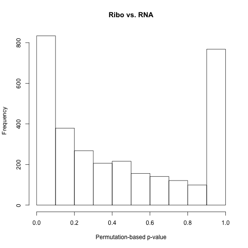

```r
load(file.path(rdadir, "null_interact_species.rda"))
hist(riborna_perm_species, main = "Ribo vs. RNA",
     xlab = "Permutation-based p-value")
```

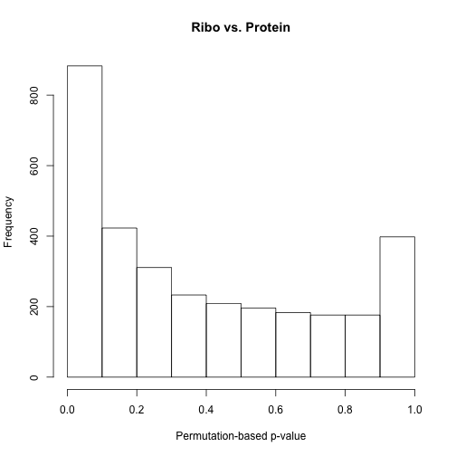

```r
hist(ribopro_perm_species, main = "Ribo vs. Protein",
     xlab = "Permutation-based p-value")
```

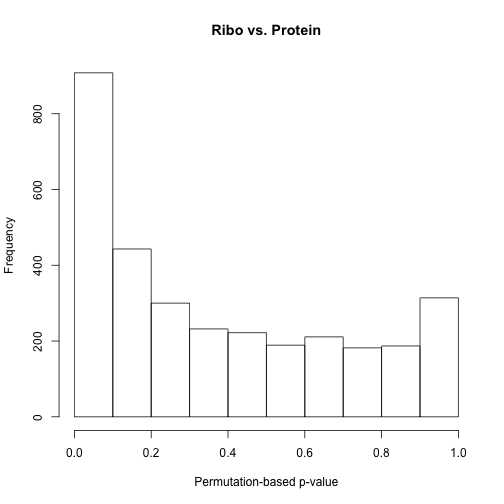

```r
hist(rnapro_perm_species, main = "Ribo vs. Protein",
     xlab = "Permutation-based p-value")
```

# Across technology and species

```r
# Permuted results are saved locally on Joyce Hsiao's computer
# Not enough storage space on GitHub

permute_dir <- "~/Dropbox/Github/primate_ribo_rdas_permute/"

# Interaction test results
# Sample lables shuffled within technologies
load(file.path(permute_dir, "permute-per-gene", "res-null-ribo-rna-per-gene.rda"))
load(file.path(permute_dir, "permute-per-gene", "res-null-ribo-pro-per-gene.rda"))
load(file.path(permute_dir, "permute-per-gene", "res-null-rna-pro-per-gene.rda"))
```

Each of the rdas contains 1,000 data.frames of 3,188 genes' results of Likelihood ratio statistics, associated p-values, and q-values (using qvalue package).

```r
load(file.path(rdadir, "diff_diver_LR.rda"))

# Compute empirical p-value for every gene
riborna_perm <- get_perm_pvals(res_null_ribo_rna_per_gene, res.riborna_LR)
ribopro_perm <- get_perm_pvals(res_null_ribo_pro_per_gene, res.ribopro_LR)
rnapro_perm <- get_perm_pvals(res_null_rna_pro_per_gene, res.rnapro_LR)


save(riborna_perm, ribopro_perm,
     rnapro_perm, file = file.path(rdadir, "null_interact.rda") )
```

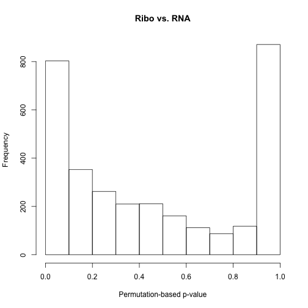

```r
load(file.path(rdadir, "null_interact.rda"))

hist(riborna_perm, main = "Ribo vs. RNA",
     xlab = "Permutation-based p-value")
```

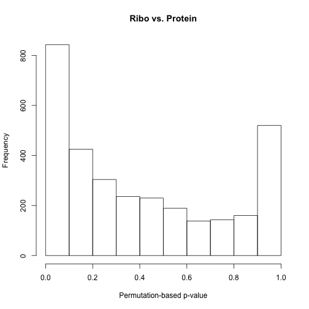

```r
hist(ribopro_perm, main = "Ribo vs. Protein",
     xlab = "Permutation-based p-value")
```

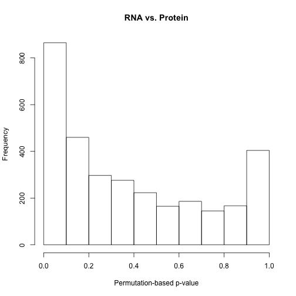

```r
hist(rnapro_perm, main = "RNA vs. Protein",
     xlab = "Permutation-based p-value")
```

```r
## R version 3.2.1 (2015-06-18)
## Platform: x86_64-apple-darwin13.4.0 (64-bit)
## Running under: OS X 10.10.4 (Yosemite)
##
## locale:
## [1] en_US.UTF-8/en_US.UTF-8/en_US.UTF-8/C/en_US.UTF-8/en_US.UTF-8
##
## attached base packages:
## [1] parallel  stats     graphics  grDevices utils     datasets  methods
## [8] base
##
## other attached packages:
## [1] Humanzee_0.0.0.9000 devtools_1.9.0      broman_0.59-5
## [4] Biobase_2.28.0      BiocGenerics_0.14.0 knitr_1.11
##
## loaded via a namespace (and not attached):
##  [1] digest_0.6.8         assertthat_0.1       mime_0.4
##  [4] knitrBootstrap_1.0.0 formatR_1.2          magrittr_1.5
##  [7] evaluate_0.7.2       stringi_0.5-5        rmarkdown_0.8
## [10] tools_3.2.1          stringr_1.0.0        markdown_0.7.7
## [13] yaml_2.1.13          memoise_0.2.1        htmltools_0.2.6
```

Styled with knitrBootstrap